# Python Statistical Analysis in Practice — 02: Descriptive Statistics & EDA

### 3.3 Coefficient of Variation (CV): Comparing Groups on Different Scales

Standard deviation is in the same unit as the data, making it impossible to directly compare spread across groups with different means (e.g. height in cm vs. weight in kg). The **Coefficient of Variation** solves this:

$$\text{CV} = \frac{\sigma}{\mu} \times 100\%$$

CV is dimensionless — a higher CV means *more relative variability*.

```python
# Compare variability across groups with different scales
groups = {
    'Height (cm)':   RNG.normal(170, 8,   size=300),
    'Weight (kg)':   RNG.normal(65,  10,  size=300),
    'Income (k¥)':   RNG.lognormal(4, 0.6, size=300),
    'Age (years)':   RNG.normal(35,  7,   size=300),
}

print(f'{"Group":<18}  {"Mean":>8}  {"Std":>8}  {"CV":>8}')
print('-' * 50)
for name, data in groups.items():
    mu  = data.mean()
    sig = data.std(ddof=1)
    cv  = sig / mu * 100
    print(f'{name:<18}  {mu:>8.2f}  {sig:>8.2f}  {cv:>7.1f}%')

print()
print('Interpretation:')
print('  Income has the highest CV (~60%) → relatively the most variable.')
print('  Height has the lowest CV (~5%)  → relatively the most uniform.')
print('  You cannot compare Std directly across these groups (different units),')
print('  but CV gives a fair comparison.')
```

```
Group                   Mean       Std        CV
--------------------------------------------------
Height (cm)           170.38      8.40      4.9%
Weight (kg)            65.69     10.44     15.9%
Income (k¥)            64.87     41.21     63.5%
Age (years)            35.08      7.27     20.7%

Interpretation:
  Income has the highest CV (~60%) → relatively the most variable.
  Height has the lowest CV (~5%)  → relatively the most uniform.
  You cannot compare Std directly across these groups (different units),
  but CV gives a fair comparison.
```

## Part 4: Distribution Shape — Skewness and Kurtosis

Summary statistics (mean, std) describe location and spread, but they say nothing about the *shape* of the distribution. Two additional statistics capture shape:

### 4.1 Skewness: Asymmetry

$$\text{Skewness} = \frac{1}{n}\sum\left(\frac{x_i - \bar{x}}{s}\right)^3$$

| Value | Shape | Typical examples |
| --- | --- | --- |
| ≈ 0 | Symmetric | Height, exam scores |
| > 0 (positive/right skew) | Long **right** tail | Income, waiting times, counts |
| < 0 (negative/left skew) | Long **left** tail | Age at death, test max-scores |

**Rule of thumb:** |skewness| > 1 warrants attention; consider log-transform.

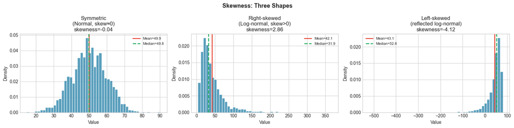

```
Notice how mean > median for right-skewed data (long right tail pulls mean up),
and mean < median for left-skewed data.
```

```python
# Simulate three shape scenarios
shapes = {
    'Symmetric\n(Normal, skew≈0)':      RNG.normal(loc=50, scale=10, size=2000),
    'Right-skewed\n(Log-normal, skew>0)': RNG.lognormal(mean=3.5, sigma=0.7, size=2000),
    'Left-skewed\n(reflected log-normal)': -RNG.lognormal(mean=3.5, sigma=0.7, size=2000) + 2*np.exp(3.5+0.7**2/2),
}

fig, axes = plt.subplots(1, 3, figsize=(16, 4))
fig.suptitle('Skewness: Three Shapes', fontsize=13, fontweight='bold')

for ax, (name, data) in zip(axes, shapes.items()):
    skew = stats.skew(data)
    ax.hist(data, bins=50, density=True, color=COLORS['primary'], edgecolor='white', alpha=0.8)
    ax.axvline(data.mean(),     color=COLORS['danger'],  lw=2, linestyle='-',  label=f'Mean={data.mean():.1f}')
    ax.axvline(np.median(data), color=COLORS['success'], lw=2, linestyle='--', label=f'Median={np.median(data):.1f}')
    ax.set_title(f'{name}\nskewness={skew:.2f}')
    ax.set_xlabel('Value'); ax.set_ylabel('Density')
    ax.legend(fontsize=8)

plt.tight_layout()
plt.show()

print('Notice how mean > median for right-skewed data (long right tail pulls mean up),')
print('and mean < median for left-skewed data.')
```

### 4.2 Kurtosis: Tail Heaviness

$$\text{Excess\ Kurtosis} = \frac{1}{n}\sum\left(\frac{x_i - \bar{x}}{s}\right)^4 - 3$$

The −3 makes the Normal distribution the reference (excess kurtosis = 0).

| Excess kurtosis | Name | Shape | Examples |
| --- | --- | --- | --- |
| ≈ 0 | Mesokurtic | Normal-like tails | Heights |
| > 0 | Leptokurtic | **Fat tails** — extreme values more common | Financial returns, network degrees |
| < 0 | Platykurtic | **Thin tails** — values concentrated near centre | Uniform, bounded variables |

> **Why care?** Fat-tailed data violates normality assumptions in many statistical tests. Outliers are more frequent than expected.

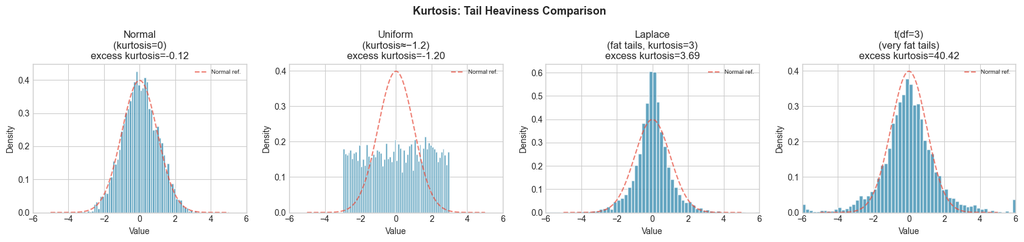

[output not shown]

```python
# Compare kurtosis across four distributions
kurt_examples = {
    'Normal\n(kurtosis=0)':           RNG.normal(0, 1, size=5000),
    'Uniform\n(kurtosis≈−1.2)':       RNG.uniform(-3, 3, size=5000),
    'Laplace\n(fat tails, kurtosis=3)': RNG.laplace(0, 1/np.sqrt(2), size=5000),
    't(df=3)\n(very fat tails)':       RNG.standard_t(df=3, size=5000),
}

fig, axes = plt.subplots(1, 4, figsize=(17, 4))
fig.suptitle('Kurtosis: Tail Heaviness Comparison', fontsize=13, fontweight='bold')

x_range = np.linspace(-5, 5, 300)
for ax, (name, data) in zip(axes, kurt_examples.items()):
    kurt = stats.kurtosis(data)   # excess kurtosis
    data_clip = np.clip(data, -6, 6)
    ax.hist(data_clip, bins=60, density=True, color=COLORS['primary'], edgecolor='white', alpha=0.75)
    # Overlay normal for reference
    ax.plot(x_range, stats.norm.pdf(x_range), color=COLORS['danger'],
            lw=1.5, linestyle='--', alpha=0.7, label='Normal ref.')
    ax.set_xlim(-6, 6)
    ax.set_title(f'{name}\nexcess kurtosis={kurt:.2f}')
    ax.set_xlabel('Value'); ax.set_ylabel('Density')
    ax.legend(fontsize=7)

plt.tight_layout()
plt.show()

print('The Laplace and t(df=3) distributions have much heavier tails than the Normal.')
print('For t(df=3), extreme events (|x|>3) are about 3× more frequent than Normal.')
```

## Part 5: The EDA Visualisation Toolkit

Five plots cover 95% of univariate EDA needs. Know when to use each.

| Plot | Strength | Weakness |
| --- | --- | --- |
| Histogram | Easy to interpret, shows density | Sensitive to bin width choice |
| KDE (kernel density) | Smooth; good for overlaying groups | Can extend past real data boundaries |
| Boxplot | Compact; great for many groups side-by-side | Hides bimodality |
| Violin | Combines KDE + boxplot | Can be misleading with small n |
| Q-Q plot | Direct normality test | Requires understanding of quantile theory |

### 5.1 Histogram: Bin Width Matters

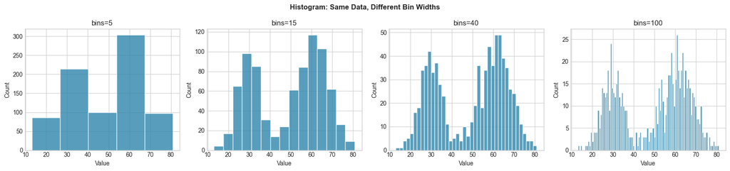

```
Rule of thumb for bin count:
  Sturges: k = ⌈log₂(n) + 1⌉ = 11
  Square root: k = ⌈√n⌉         = 29
  Freedman-Diaconis (scipy default): automatic, data-driven

  → For EDA, try 2-3 bin counts. If bimodality appears at one setting
    and disappears at another, report both and investigate.
```

```python
# Demonstrate how bin width changes the story
sample_data = np.concatenate([
    RNG.normal(30, 5, 300),
    RNG.normal(60, 8, 500),
])  # bimodal

fig, axes = plt.subplots(1, 4, figsize=(17, 4))
fig.suptitle('Histogram: Same Data, Different Bin Widths', fontsize=12, fontweight='bold')

for ax, bins in zip(axes, [5, 15, 40, 100]):
    ax.hist(sample_data, bins=bins, color=COLORS['primary'], edgecolor='white', alpha=0.8)
    ax.set_title(f'bins={bins}')
    ax.set_xlabel('Value'); ax.set_ylabel('Count')

plt.tight_layout()
plt.show()

print('Rule of thumb for bin count:')
print('  Sturges: k = ⌈log₂(n) + 1⌉ =', int(np.ceil(np.log2(len(sample_data))+1)))
print('  Square root: k = ⌈√n⌉         =', int(np.ceil(np.sqrt(len(sample_data)))))
print('  Freedman-Diaconis (scipy default): automatic, data-driven')
print()
print('  → For EDA, try 2-3 bin counts. If bimodality appears at one setting')
print('    and disappears at another, report both and investigate.')
```

### 5.2 KDE: Smoother than a Histogram

A Kernel Density Estimate places a small "bump" (kernel) at each data point and sums them into a smooth curve. It is ideal for overlaying two or more groups.

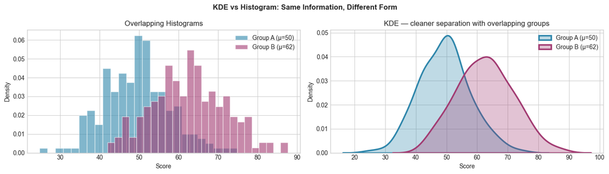

```python
group_a = RNG.normal(loc=50, scale=8,  size=200)
group_b = RNG.normal(loc=62, scale=10, size=200)

fig, axes = plt.subplots(1, 2, figsize=(14, 4))
fig.suptitle('KDE vs Histogram: Same Information, Different Form', fontsize=12, fontweight='bold')

# Left: histograms
axes[0].hist(group_a, bins=25, density=True, color=COLORS['primary'], alpha=0.6,
             edgecolor='white', label='Group A (μ=50)')
axes[0].hist(group_b, bins=25, density=True, color=COLORS['secondary'], alpha=0.6,
             edgecolor='white', label='Group B (μ=62)')
axes[0].set_title('Overlapping Histograms')
axes[0].set_xlabel('Score'); axes[0].set_ylabel('Density')
axes[0].legend()

# Right: KDE
sns.kdeplot(group_a, ax=axes[1], color=COLORS['primary'],   linewidth=2.5,
            fill=True, alpha=0.3, label='Group A (μ=50)')
sns.kdeplot(group_b, ax=axes[1], color=COLORS['secondary'], linewidth=2.5,
            fill=True, alpha=0.3, label='Group B (μ=62)')
axes[1].set_title('KDE — cleaner separation with overlapping groups')
axes[1].set_xlabel('Score'); axes[1].set_ylabel('Density')
axes[1].legend()
plt.tight_layout()
plt.show()
```

### 5.3 Boxplot, Violin, and Strip Plot: Three Views of Group Comparison

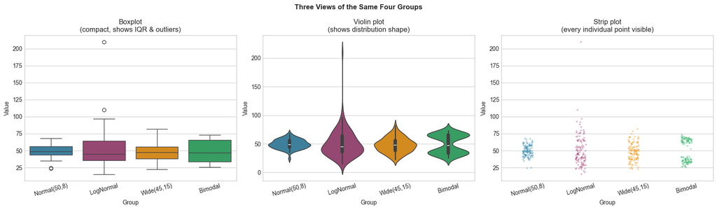

```
The "Bimodal" group has two distinct clusters.
  Boxplot: looks like a normal wide distribution — MISSES the bimodality.
  Violin:  clearly shows two bumps — REVEALS the bimodality.
  Strip:   individual points show two clusters — CONFIRMS bimodality.

→ Never use boxplot alone when you suspect non-unimodal distributions.
```

```python
# Generate four groups with different shapes for comparison
n_per = 120
groups_df = pd.DataFrame({
    'value': np.concatenate([
        RNG.normal(50, 8,   n_per),
        RNG.lognormal(3.8, 0.4, n_per),
        RNG.normal(45, 15,  n_per),
        np.concatenate([RNG.normal(35,4,n_per//2), RNG.normal(65,4,n_per//2)]),
    ]),
    'group': (['Normal(50,8)'] * n_per +
              ['LogNormal'] * n_per +
              ['Wide(45,15)'] * n_per +
              ['Bimodal'] * n_per),
})

fig, axes = plt.subplots(1, 3, figsize=(17, 5))
fig.suptitle('Three Views of the Same Four Groups', fontsize=12, fontweight='bold')

palette = [COLORS['primary'], COLORS['secondary'], COLORS['accent'], COLORS['success']]

# Boxplot
sns.boxplot(data=groups_df, x='group', y='value', ax=axes[0], palette=palette)
axes[0].set_title('Boxplot\n(compact, shows IQR & outliers)')
axes[0].set_xlabel('Group'); axes[0].set_ylabel('Value')
axes[0].tick_params(axis='x', rotation=15)

# Violin
sns.violinplot(data=groups_df, x='group', y='value', ax=axes[1], palette=palette, inner='box')
axes[1].set_title('Violin plot\n(shows distribution shape)')
axes[1].set_xlabel('Group'); axes[1].set_ylabel('Value')
axes[1].tick_params(axis='x', rotation=15)

# Strip plot
sns.stripplot(data=groups_df, x='group', y='value', ax=axes[2],
              palette=palette, alpha=0.35, size=3, jitter=True)
axes[2].set_title('Strip plot\n(every individual point visible)')
axes[2].set_xlabel('Group'); axes[2].set_ylabel('Value')
axes[2].tick_params(axis='x', rotation=15)

plt.tight_layout()
plt.show()

print('The "Bimodal" group has two distinct clusters.')
print('  Boxplot: looks like a normal wide distribution — MISSES the bimodality.')
print('  Violin:  clearly shows two bumps — REVEALS the bimodality.')
print('  Strip:   individual points show two clusters — CONFIRMS bimodality.')
print()
print('→ Never use boxplot alone when you suspect non-unimodal distributions.')
```